# Análisis de la Temperatura en Málaga (1960-2023)

Análisis de Series Temporales - BLOQUE I

Frank Salomón Sulca Palomino

# Resumen

Este informe analiza la serie temporal de las temperaturas en la ciudad de Málaga desde enero de 1960 hasta diciembre de 2023. Se examinarán patrones de temperatura, tendencias, y variaciones estacionales. Además, se aplicarán métodos estadísticos para determinar la estacionariedad y las proyecciones futuras con el modelo ARMA y SARIMA.

# Análisis preliminar de la serie

**1. Representa gráficamente la serie para analizar su comportamiento general y analiza si hay algún problema de heterogeneidad de varianza (si ese fuera el caso, transforma la variable para resolverlo; solo si la transformación mejora la heterocedasticidad). Describe si la serie muestra alguna desviación del comportamiento estacionario en la media.**

En primer lugar, se identificó la presencia de valores faltantes en la serie temporal, con un total de 19 datos ausentes entre 1983 y 2001, de los cuales 10 correspondían a valores consecutivos en el año 1990, a continuación se verifica ello:

```
##    Año Cantidad_NA
## 1 1983           1
## 2 1988           1
## 3 1989           3
## 4 1990          10
## 5 1997           1
## 6 2001           3
```

Para abordar este problema se utilizó la función `na_seadec()` del paquete **imputeTS**, una herramienta especializada en la imputación de datos en series temporales, se estiman los valores faltantes utilizando los patrones estacionales y cíclicos presentes en la serie. Este enfoque garantiza que la imputación respete la estructura temporal de los datos, lo cual es crucial para preservar la integridad de la serie y asegurar la validez de los análisis posteriores.

Esto resulta especialmente relevante para la aplicación de modelos predictivos avanzados, como ARMA y SARIMA, los cuales requieren series completas y estacionarias para obtener estimaciones precisas y confiable, a continuacion se muestra la serie orginal e imputada.

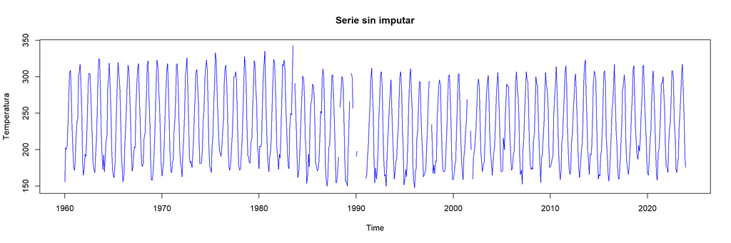

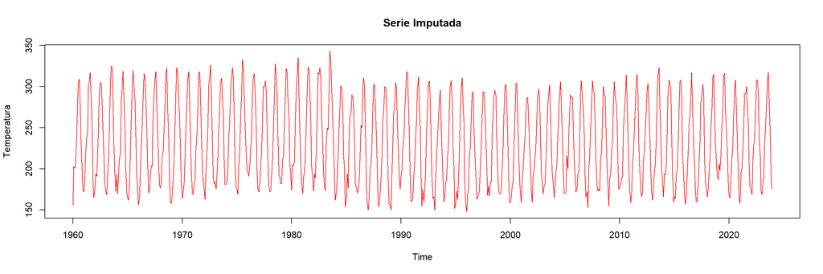

Para verificar la estacionariedad de la serie imputada, que a partir de ahora se denominará serie original, se llevó a cabo la prueba de Dickey-Fuller aumentada (ADF). Posteriormente, se aplicó la prueba KPSS tanto a la serie original como a su versión transformada logarítmicamente, se realizo esta transformación con el fin de evaluar si esta tenia un impacto significativo en los resultados de la prueba. Este enfoque permite comparar el comportamiento de la serie antes y después de la transformación, asegurando un análisis más robusto de su estacionariedad.

```
##               Test Statistic P.Value
## Dickey-Fuller  ADF -6.743891    0.01
```

```
##                            Test Statistic P.Value
## 1         KPSS a serie Original 0.1874451     0.1
## 2 KPSS a serie transformada Log 0.1693069     0.1
```

```
## Media de los residuos estandarizados: -3.752582e-17
```

```
## Desviación estándar de los residuos estandarizados: 1
```

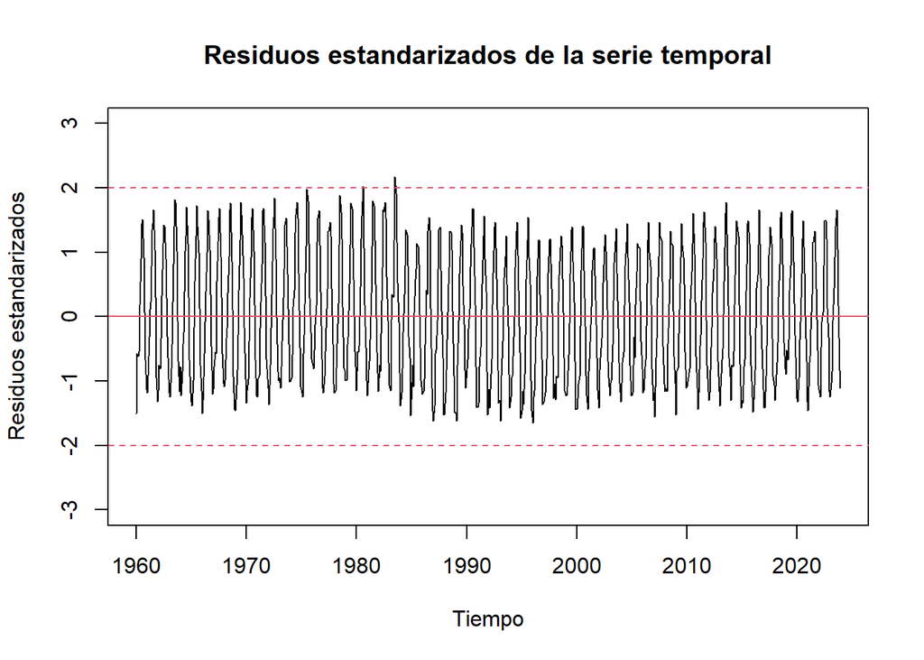

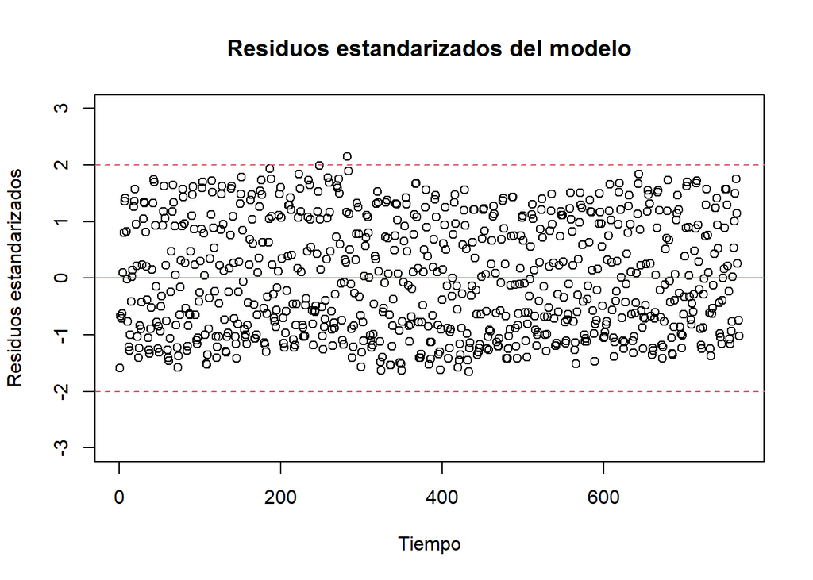

**2. Estima la tendencia y la componente estacional utilizando el metodo mas adecuado. Indica el metodo de estimacion que has utilizado y el valor de los parametros que hayas seleccionado para la estimacion; indica los valores de los parametros que hayas ensayado, pero muestra solo los detalles y resultados de la estimacion final. Compara las estimaciones obtenidas con las proporcionadas por la funcion stl.**

Se procede a estimar la tendencia de la serie temporal, para ello utilicé un modelo de regresión lineal simple, ya que proporcionó un buen ajuste visual. Probé también un modelo cuadrático, pero no mejoró signi ficativamente los resultados en comparación con el modelo lineal. Además, apliqué un suavizado utilizando medias móviles con una ventana de 12 meses (rollmean()), lo cual resultó ser el mejor enfoque para equilibrar el suavizado y el ajuste de la serie temporal.

Para estimar la componente estacional, utilicé las medias estacionales, calculadas mediante la función tapply(), donde agrupo los datos por el ciclo anual de la serie temporal (12 meses). Probé diferentes configuraciones para la duración del periodo estacional (6, 12 y 24 meses) y seleccioné 12 meses como el periodo óptimo, ya que representó de manera más precisa los patrones estacionales observados en la serie, dado que el clima presenta un patron ciclico el cual se piede representar con la funcion seasonplot a continuacion:

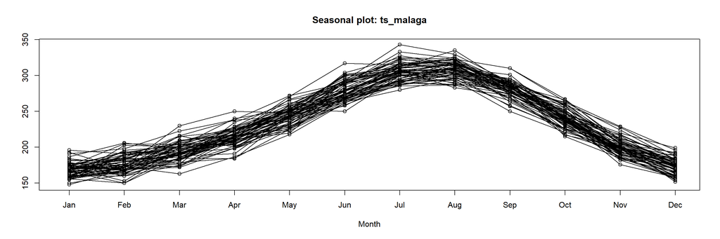

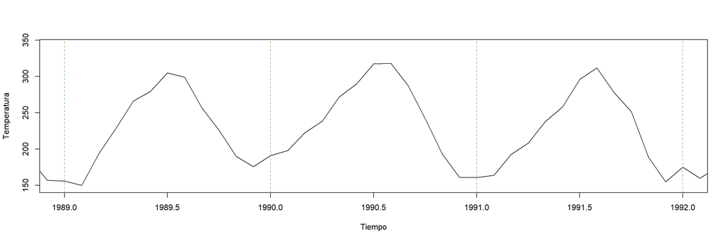

Finalmente, comparé las estimaciones obtenidas con las generadas por la función stl(), que descompone la serie en componentes de tendencia, estacionalidad y residuales. Los resultados obtenidos a partir de ambos métodos coincidieron en gran medida, lo que validó las decisiones tomadas respecto a la selección de parámetros y metodologías.

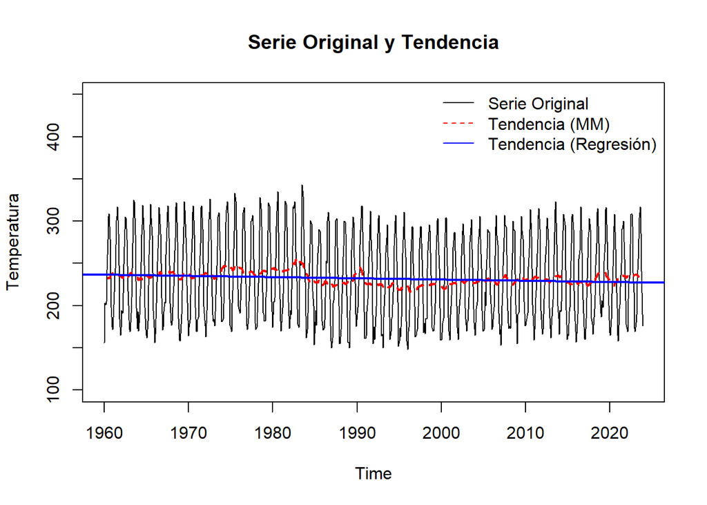

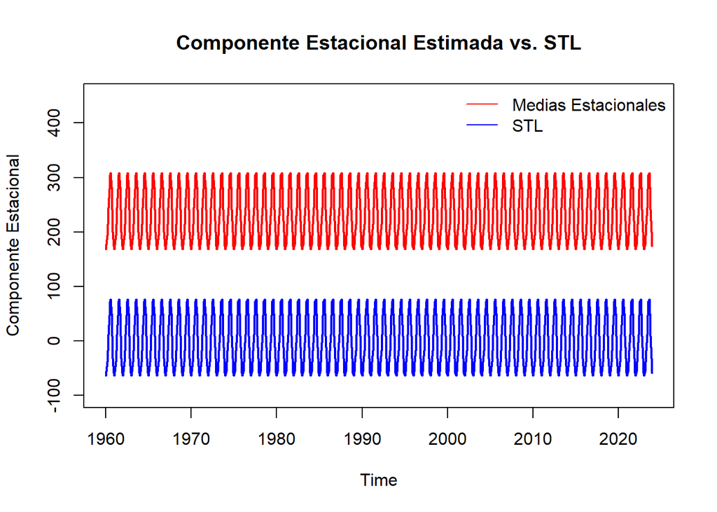

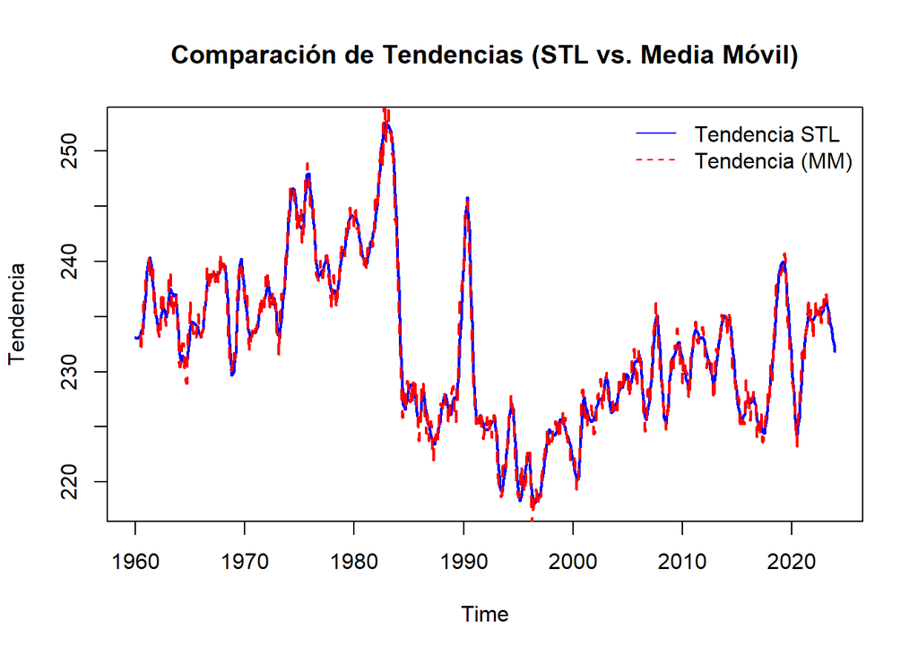

**3. Convierte la serie en una serie estacionaria diferenciando de la forma necesaria para eliminar la componente estacional y la tendencia.**

Se realizo la prueba ADF Y KPSS a la serie original y luego a la serie diferenciada para comprobar que la serie sea estacionaria.

```
##               Prueba Estadístico P_Valor
## 1       ADF Original -6.74389120    0.01
## 2      KPSS Original  0.18744514    0.10
## 3  ADF Dif. (Lag=12) -8.05371524    0.01
## 4 KPSS Dif. (Lag=12)  0.02926421    0.10
```

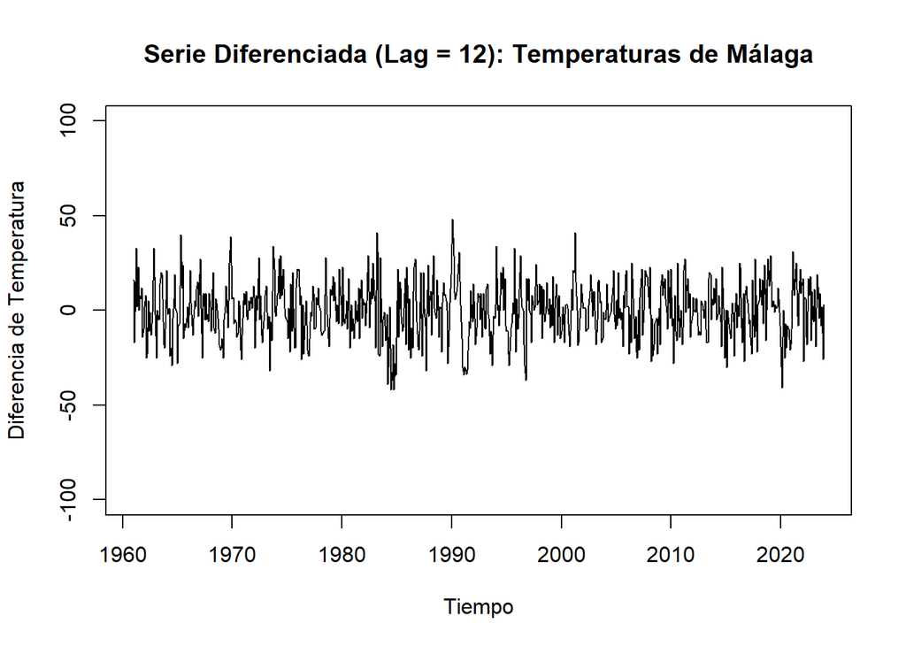

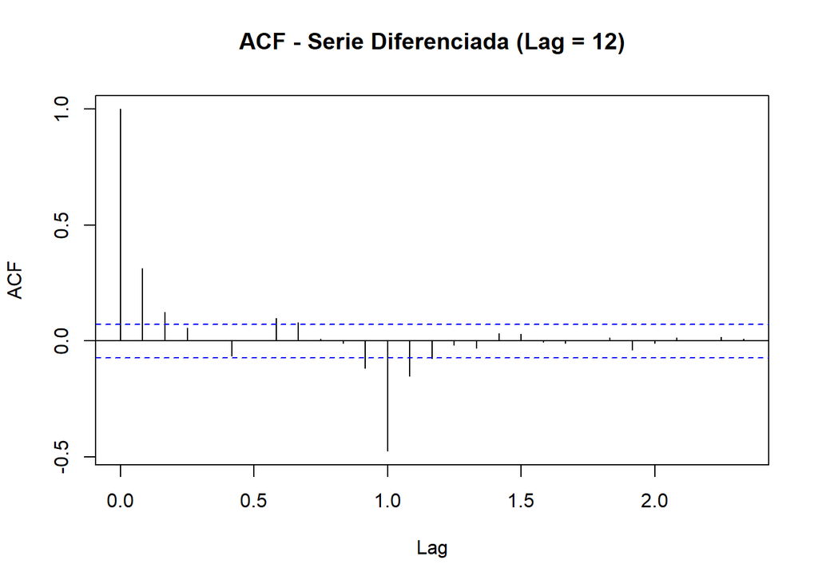

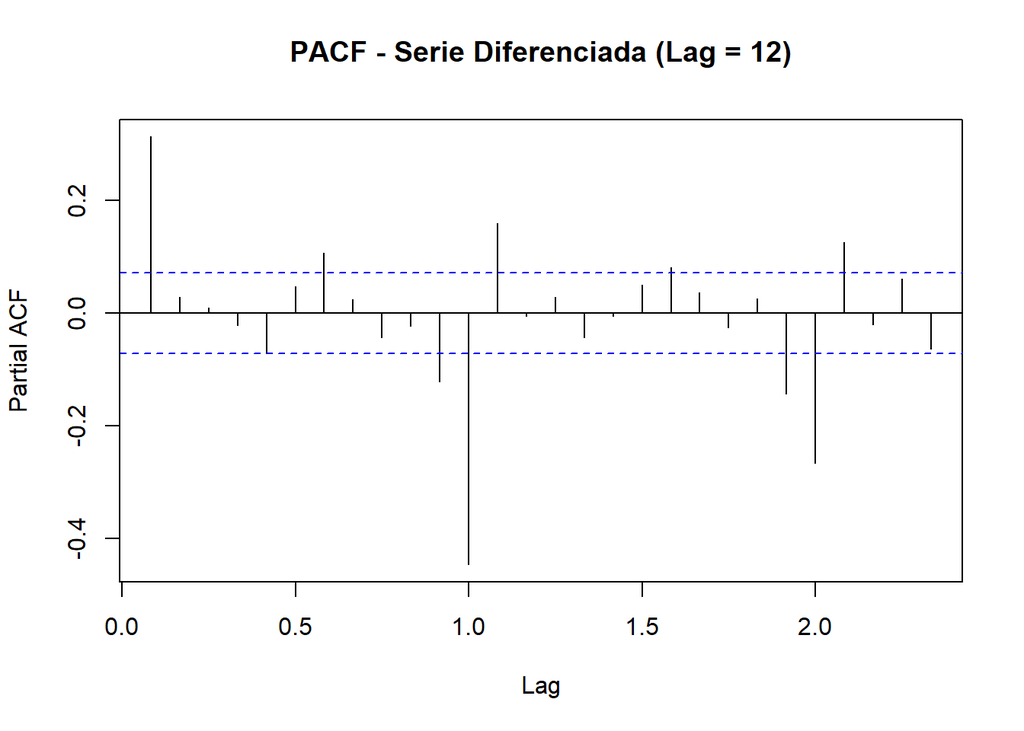

### MODELIZACIÓN DE LA SERIE

**1. Analiza si es útil plantear un modelo tipo ARMA para la serie.**

Dado que la serie diferenciada es estacionaria y los gráficos ACF y PACF sugieren una estructura ARMA, es razonable considerar un modelo ARMA. Sin embargo, la dependencia estacional residual en el rezago 12 indica que un modelo ARMA podría no ser suficiente por sí solo, haciendo más adecuado un modelo SARIMA, que incluye componentes estacionales. Por tanto, se necesita un análisis más profundo para ajustar el modelo ARMA adecuado y verificar sus coeficientes.

**2. Selecciona de forma razonada el modelo ARMA que creas mas adecuado (NO se puede utilizar como criterio la orden auto.arima) y muestra el modelo ajustado. Contrasta si los coeficientes del modelo son iguales a 0 (cada uno de forma individual).**

Selección preliminar del modelo AR:

```
## [1] "AIC para AR( 1 ): 6144.28231682298"
## [1] "AIC para AR( 2 ): 6145.67648292866"
## [1] "AIC para AR( 3 ): 6147.58807725169"
## [1] "AIC para AR( 4 ): 6149.2690031121"
## [1] "AIC para AR( 5 ): 6147.46303221472"
## [1] "AIC para AR( 6 ): 6147.64241684272"
## [1] "AIC para AR( 7 ): 6140.93554178591"
## [1] "AIC para AR( 8 ): 6142.4974242289"
## [1] "AIC para AR( 9 ): 6143.10085457657"
## [1] "AIC para AR( 10 ): 6144.70994074334"
```

Selección preliminar del modelo MA:

```
## [1] "AIC para MA( 1 ): 6153.78203206652"
## [1] "AIC para MA( 2 ): 6147.95380060636"
## [1] "AIC para MA( 3 ): 6147.6400270919"
## [1] "AIC para MA( 4 ): 6147.74534267556"
## [1] "AIC para MA( 5 ): 6145.89807270509"
## [1] "AIC para MA( 6 ): 6134.68055829335"
## [1] "AIC para MA( 7 ): 6136.17185968472"
## [1] "AIC para MA( 8 ): 6111.92395912601"
## [1] "AIC para MA( 9 ): 6112.89838807886"
## [1] "AIC para MA( 10 ): 6057.31347873293"
```

Selección preliminar del modelo ARMA:

```
## AIC para ARMA( 1 , 1 ): 6145.649
## AIC para ARMA( 1 , 2 ): 6147.646
## AIC para ARMA( 1 , 3 ): 6149.099
## AIC para ARMA( 1 , 4 ): 6148.088
## AIC para ARMA( 2 , 1 ): 6147.648
## AIC para ARMA( 2 , 2 ): 6149.627
## AIC para ARMA( 2 , 3 ): 6068.19
## AIC para ARMA( 2 , 4 ): 6100.829
## AIC para ARMA( 3 , 1 ): 6139.363
## AIC para ARMA( 3 , 2 ): 6083.644
## AIC para ARMA( 3 , 3 ): 6082.184
## AIC para ARMA( 3 , 4 ): 6070.756
## AIC para ARMA( 4 , 1 ): 6151.451
## AIC para ARMA( 4 , 2 ): 6112.337
## AIC para ARMA( 4 , 3 ): 6044.98
## AIC para ARMA( 4 , 4 ): 6016.956
```

Ajuste de los mejores modelos

Ajustar modelo ARMA(4,3)

[output not shown]

Selección del modelo

[output not shown]

**3. Valida el modelo utilizando las herramientas adecuadas e indica cual es la comprobacion mas importante.**

```
## Media de los residuos estandarizados: 3.715935e-05
```

```
## Desviación estándar de los residuos estandarizados: 1
```

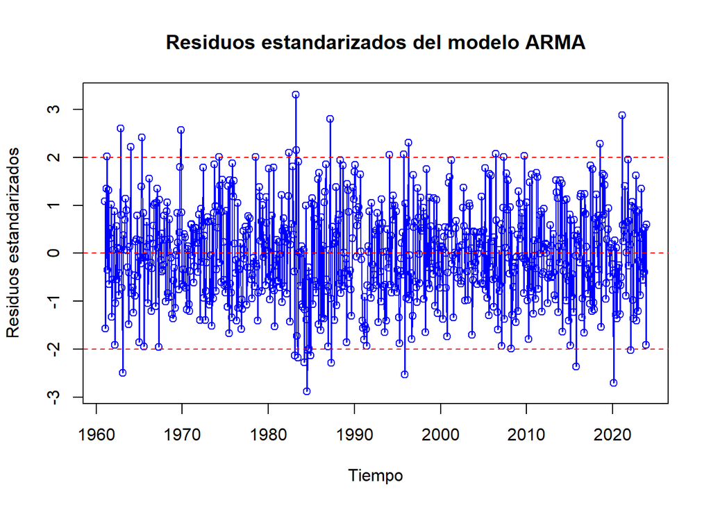

se realiza la Prueba de normalidad Shapiro-Wilk y Prueba de Ljung-Box:

```
##
##  Shapiro-Wilk normality test
##
## data:  residuos
## W = 0.9982, p-value = 0.6246
```

```
##
##  Box-Ljung test
##
## data:  residuos
## X-squared = 151.84, df = 20, p-value < 2.2e-16
```

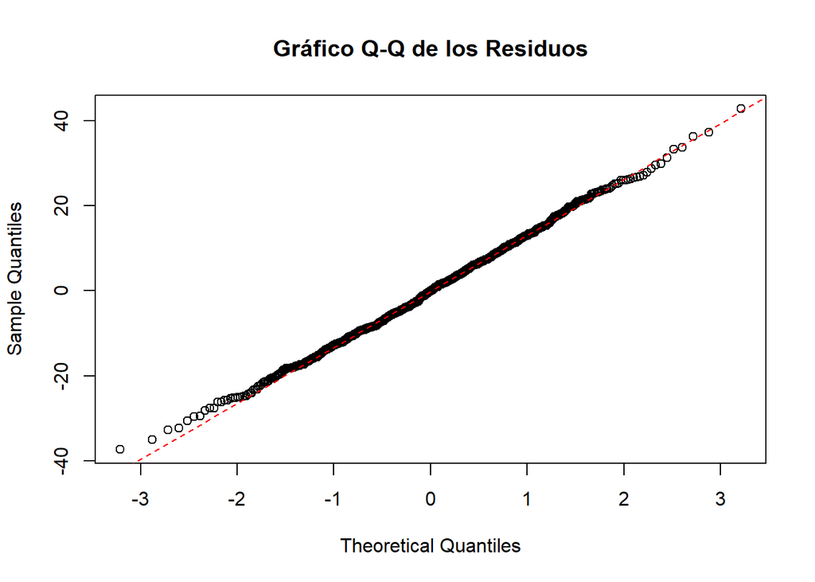

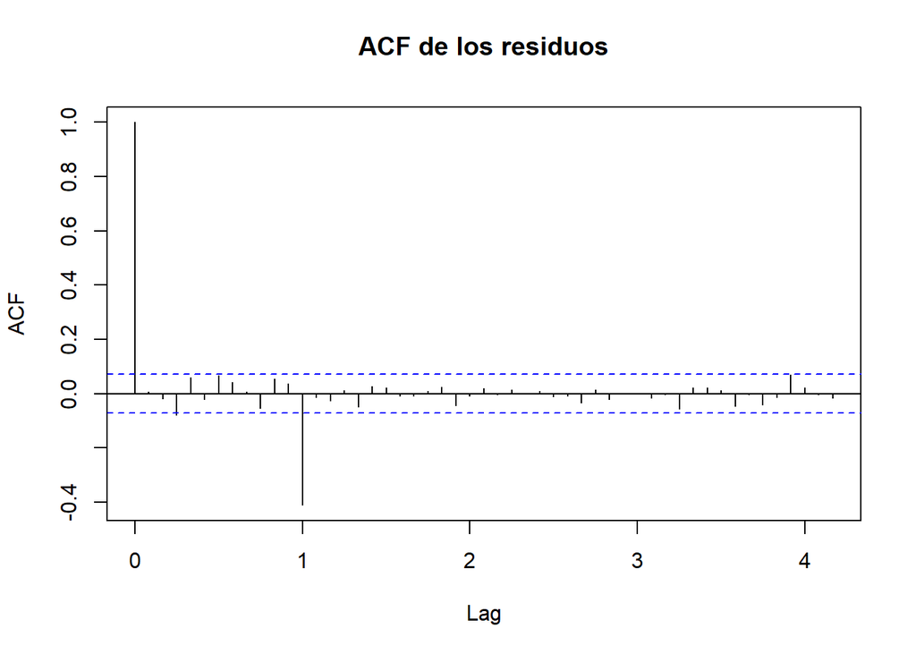

Los resultados obtenidos en la validación del modelo ARMA(4,3) evidencian aspectos importantes sobre su desempeño. La prueba de Ljung-Box arroja un estadístico X-squared = 151.84, con 20 grados de libertad y un p-valor menor a 2.2e-16, lo que indica que los residuos no son independientes. Este resultado sugiere que el modelo no ha logrado capturar completamente la estructura de autocorrelación de los datos, ya que persisten patrones en los residuos que deberían haber sido eliminados.

Por otro lado, la prueba de Shapiro-Wilk reporta un estadístico W = 0.9982 y un p-valor de 0.6246, lo que confirma que los residuos siguen una distribución aproximadamente normal. Este comportamiento es consistente con un modelo que genera residuos adecuadamente distribuidos, pero no necesariamente independientes.

En resumen, el modelo ARMA(4,3) presenta limitaciones al no garantizar la independencia de los residuos y al no capturar una componente estacional evidente en el análisis de autocorrelación. Aunque cumple con la normalidad de los residuos, su desempeño general no es adecuado, por lo que se recomienda explorar enfoques que integren la estacionalidad para mejorar su capacidad predictiva.

**4. Ajusta un modelo SARIMA a la serie original, que unifique en un modelo global los resultados de los apartados anteriores. El modelo debe ser el mismo que has obtenido en el paso 2 partiendo de la serie estacionaria.**

Prueba de Ljung-Box sobre los residuos

[output not shown]

Prueba de normalidad de Shapiro-Wilk sobre los residuos

[output not shown]

```
## Media de los residuos estandarizados: 0.004324244
```

```
## Desviación estándar de los residuos estandarizados: 1
```

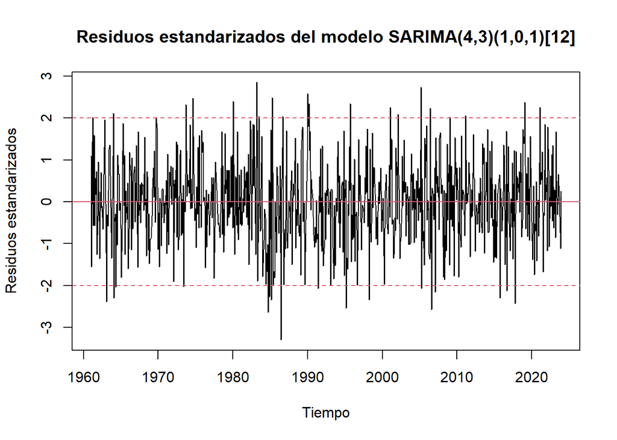

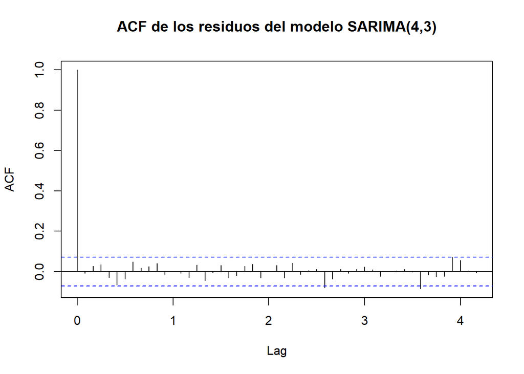

El modelo SARIMA ajustado a la serie original es un modelo estacional autoregresivo de media móvil con especificaciones ARMA(4,3) y estacionalidad (1,0,1) con un período de 12, lo que indica una estacionalidad mensual anual. Los coeficientes estimados para el modelo son los siguientes: AR1 = -0.5586, AR2 = 1.0419, AR3 = 0.7269, AR4 = -0.2501, MA1 = 0.9175, MA2 = -0.7121, MA3 = -0.9278, SAR1 = 0.0099, SMA1 = -0.9642 e intercepto = -0.0949. El error cuadrático medio (RMSE) de ajuste es de 10.17, y el MAE es de 7.98, lo que indica un rendimiento razonable en la predicción de la serie.

**5. Calcula predicciones de la serie de datos original para el proximo año. Calcula tambien intervalos de confianza al 95 % para estas predicciones y representa en el mismo grafico las predicciones y los intervalos de confianza.**

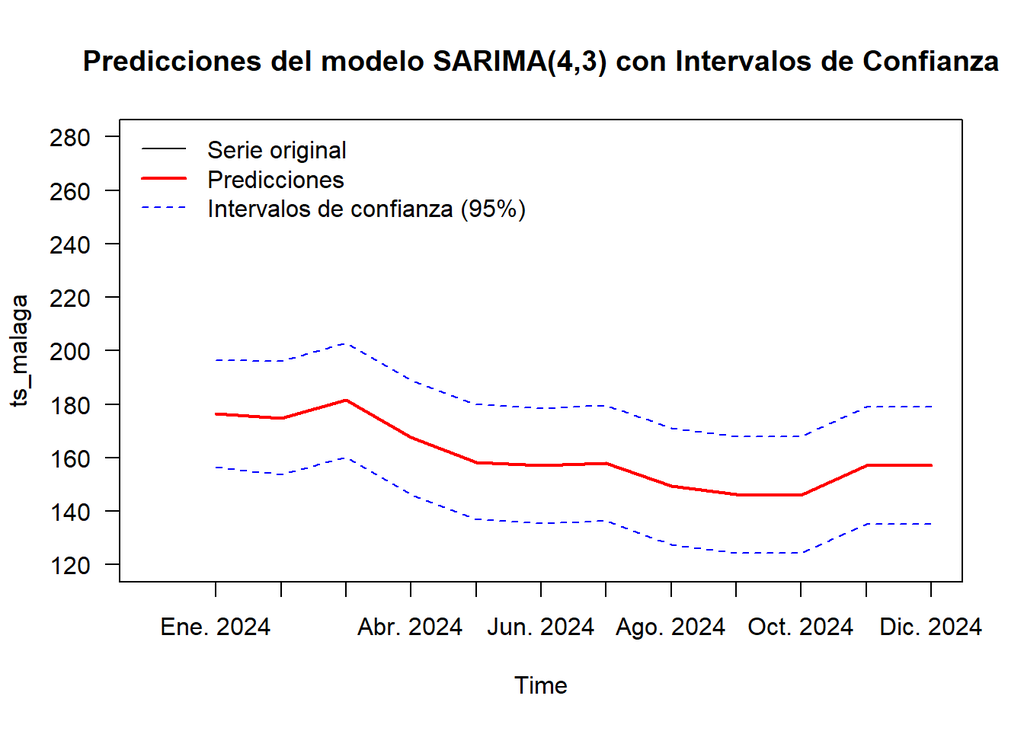

```
##          Mes Prediccion Inferior Superior
## 1  Ene. 2024   176.3366 156.3802 196.2930
## 2  Feb. 2024   174.7983 153.6101 195.9866
## 3  Mar. 2024   181.6278 160.2810 202.9745
## 4  Abr. 2024   167.6065 146.1663 189.0467
## 5  May. 2024   158.2683 136.7549 179.7817
## 6  Jun. 2024   157.0004 135.4535 178.5473
## 7  Jul. 2024   157.9609 136.3232 179.5987
## 8  Ago. 2024   149.2546 127.5968 170.9125
## 9  Set. 2024   146.1806 124.4331 167.9281
## 10 Oct. 2024   146.0388 124.2679 167.8097
## 11 Nov. 2024   157.0604 135.2253 178.8955
## 12 Dic. 2024   157.0139 135.1391 178.8886
```

**6. Analiza si existe (puede que no exista) otro modelo SARIMA que creas que es mas adequado que el obtenido en el apartado 4. Justifica en que te basas para tu decision y si encuentras un modelo mejor ajustalo.**

No se exploraron órdenes superiores a (4,3) porque, al ajustar estos modelos, se observaron coeficientes no significativos o nulos como se vio en el apartado anterior al validar el modelo ARMA, indicando que no aportaban información relevante para capturar los patrones de la serie. Además, órdenes mayores podrían introducir redundancia, dificultar la interpretación del modelo y aumentar el riesgo de sobreajuste, lo que afecta la capacidad predictiva al capturar ruido en lugar de patrones relevantes.

```r
# Establecer la organización de los gráficos

#Ajustar otros modelos SARIMA con diferentes combinaciones de parámetros
modelo_sarima_1 <- arima(dif12ts_malaga, order = c(1, 0, 1), seasonal = list(order = c(1, 0, 1), period = 12))
modelo_sarima_2 <- arima(dif12ts_malaga, order = c(2, 0, 2), seasonal = list(order = c(1, 0, 1), period = 12))
modelo_sarima_3 <- arima(dif12ts_malaga, order = c(3, 0, 3), seasonal = list(order = c(1, 0, 1), period = 12))
```

|  | df | AIC |
| --- | --- | --- |
| modelo_sarima | 11 | 5708.005 |
| modelo_sarima_1 | 6 | 5735.914 |
| modelo_sarima_2 | 8 | 5713.667 |
| modelo_sarima_3 | 10 | 5717.578 |

|  | df | BIC |
| --- | --- | --- |
| modelo_sarima | 11 | 5758.913 |
| modelo_sarima_1 | 6 | 5763.682 |
| modelo_sarima_2 | 8 | 5750.692 |
| modelo_sarima_3 | 10 | 5763.858 |

```
##            Modelo Ljung_Box_p_value
## 1   Modelo SARIMA        0.76199796
## 2 Modelo SARIMA 1        0.01476531
## 3 Modelo SARIMA 2        0.60008941
## 4 Modelo SARIMA 3        0.61624593
```

```
##            Modelo Shapiro_Wilk_p_value
## 1   Modelo SARIMA            0.1252407
## 2 Modelo SARIMA 1            0.2702042
## 3 Modelo SARIMA 2            0.1223722
## 4 Modelo SARIMA 3            0.1231830
```

Basado en los resultados obtenidos, el modelo_sarima, el cual fue nuestro modelo elegido para las predicciones, es el que muestra el mejor desempeño en comparación con los otros modelos evaluados, tiene los valores más bajos de AIC, lo que indica que es el modelo más eficiente en términos de ajuste y penalización por complejidad. Además, los residuos de este modelo no presentan autocorrelación significativa, según la prueba de Ljung-Box, lo que sugiere que ha capturado adecuadamente la estructura temporal de la serie. También, la prueba de Shapiro-Wilk revela que los residuos siguen una distribución normal, lo que es otra señal de que el modelo está bien ajustado.

No obtante, el modelo SARIMA 2 tambien cuenta con el menos BIC en comparacion a los otros modelos, asimismo en el analisis de residuos resulto muy similiar al modelo sarima elegido (4,0,3), por lo que tambien podria ser un buen modelo.

```
## Media de los residuos estandarizados: 0.00403759
```

```
## Desviación estándar de los residuos estandarizados: 1
```

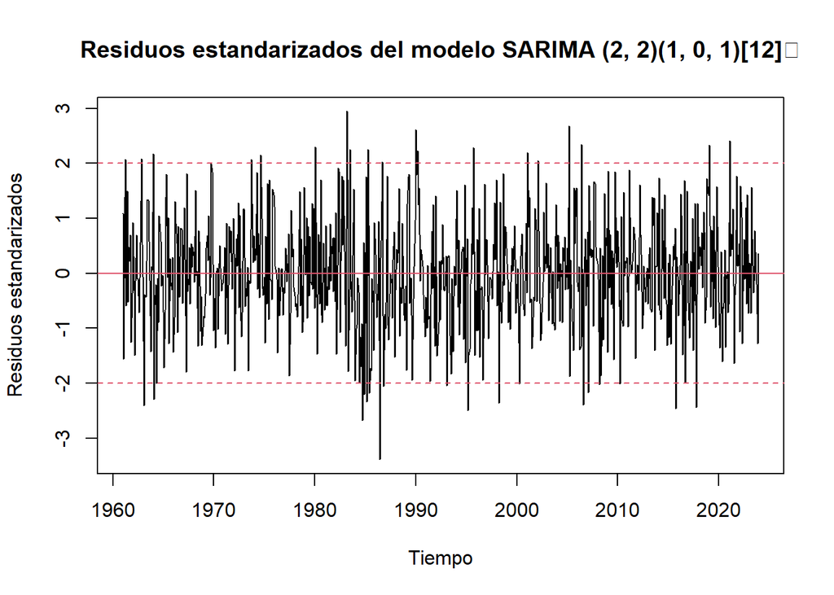

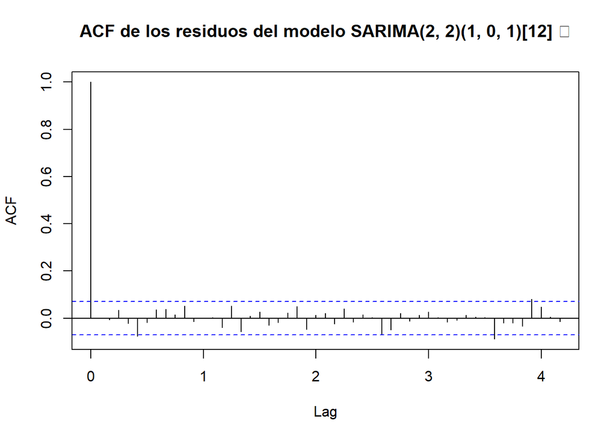

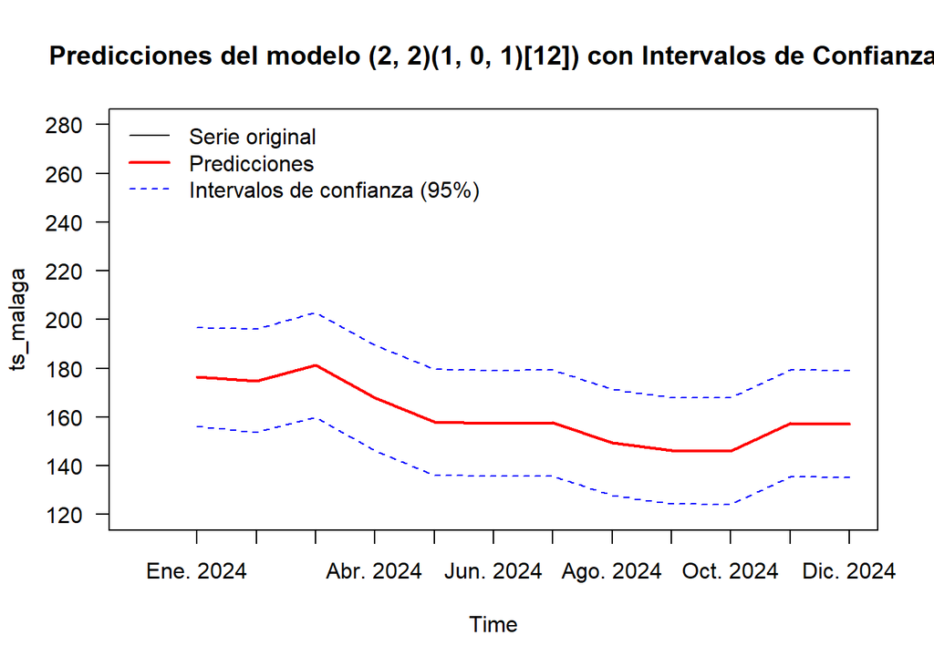

```
##          Mes Prediccion Inferior Superior
## 1  Ene. 2024   176.4671 156.3234 196.6108
## 2  Feb. 2024   174.8724 153.6666 196.0782
## 3  Mar. 2024   181.3725 159.8935 202.8514
## 4  Abr. 2024   167.9209 146.3310 189.5108
## 5  May. 2024   157.7935 136.1360 179.4510
## 6  Jun. 2024   157.3326 135.6220 179.0432
## 7  Jul. 2024   157.5886 135.8307 179.3466
## 8  Ago. 2024   149.4303 127.6279 171.2327
## 9  Set. 2024   146.1371 124.2921 167.9822
## 10 Oct. 2024   146.0180 124.1316 167.9043
## 11 Nov. 2024   157.4788 135.5523 179.4052
## 12 Dic. 2024   157.0328 135.0674 178.9982
```